# Klotho interactions with age

Anna L Tyler

March 13, 2025

## Introduction

The purpose of this workflow is to look at interactions between age and genotype in affecting gene expression.

```r
rm(list = ls())

library(here)

results.dir <- here("Results", "Age_Effects")
if(!file.exists(results.dir)){
  dir.create(results.dir, TRUE)
  }

geno.cols <- c("WT/WT" = "darkgray", "WT/VS" = "#a6bddb", "VS/VS" = "#2b8cbe", "WT/FC" = "#a1d99b", "FC/FC" = "#31a354")
#barplot(rep(1, length(geno.cols)), col = geno.cols)

general.data.dir <- here("Data", "general")
```

```r
all.fun <- list.files(here("Code"), full.names = TRUE)
for(i in 1:length(all.fun)){source(all.fun[i])}
```

```r
needed.libraries <- c("pheatmap", "gprofiler2", "vioplot")
load_libraries(needed.libraries)
```

```r
#read data from all ages analysis
adj.expr <- readRDS(here("Results", "all", "processed_data", "Adjusted_gene_Expression_for_climb_geno_test.RDS"))
covar <- read.csv(here("Results", "all", "covariates.csv"))
mouse.gene.table <- read.table(file.path(general.data.dir, "mouse_gene_info.txt"), sep = "\t", header = TRUE)
```

We first compared the variance explained by genotype at each age for every gene. The boxplot below shows that genotype explains slightly more variance at 12 months than at 4 months.

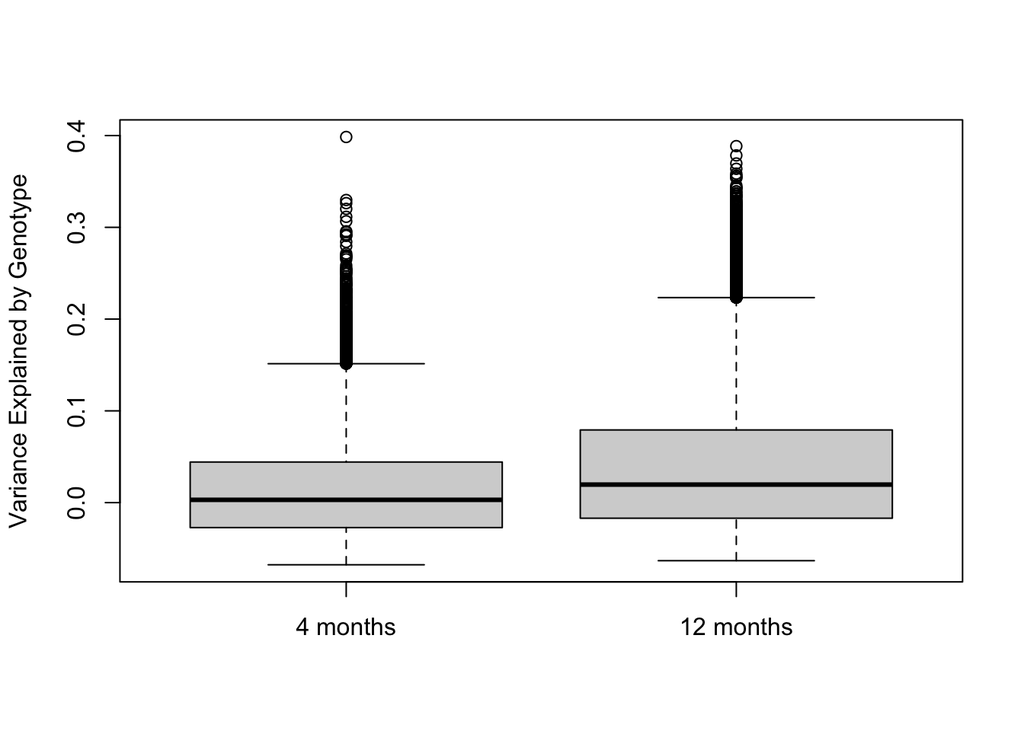

```r
#Look at the variance explained by genotype for each
#transcript in both young and old mice. See if genotype
#explains more variance in the older mice.

u_age <- unique(covar[,"age_batch"])
age.idx <- lapply(u_age, function(x) which(covar[,"age_batch"] == x))
names(age.idx)  <- paste(u_age, "months")

age.test <- lapply(age.idx, function(y) apply(adj.expr[y,], 2, function(x) lm(x~as.factor(covar[y,"climb_geno"]))))
age.r2 <- lapply(age.test, function(y) sapply(y, function(x) summary(x)$adj.r.squared))

boxplot(age.r2, ylab = "Variance Explained by Genotype")
```

The plot below shows that there isn’t a very strong relationship between variance explained at one age and variance explained at another.

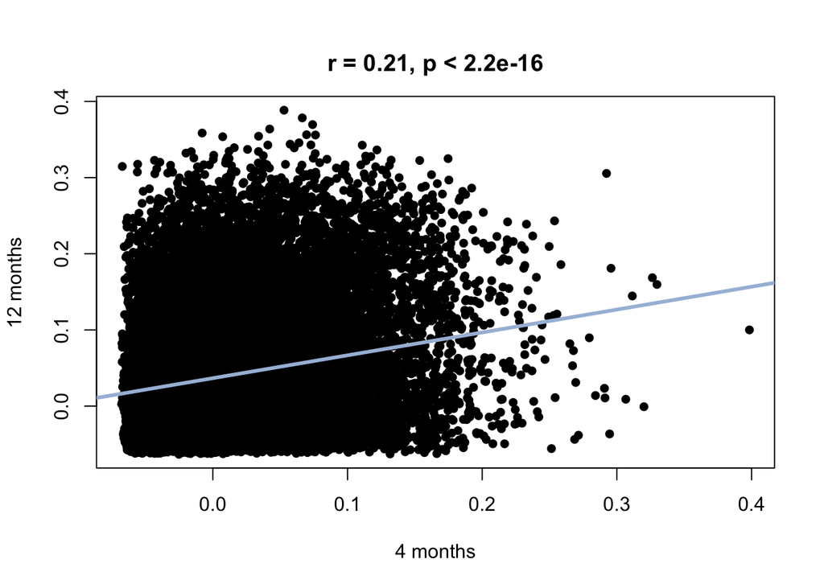

```r
plot.with.model(age.r2[[1]], age.r2[[2]], report = "cor.test",
    xlab = names(age.r2)[1], ylab = names(age.r2)[2])
```

The plots below show functional enrichments for genes for which more variance is explained by genotype at different ages.

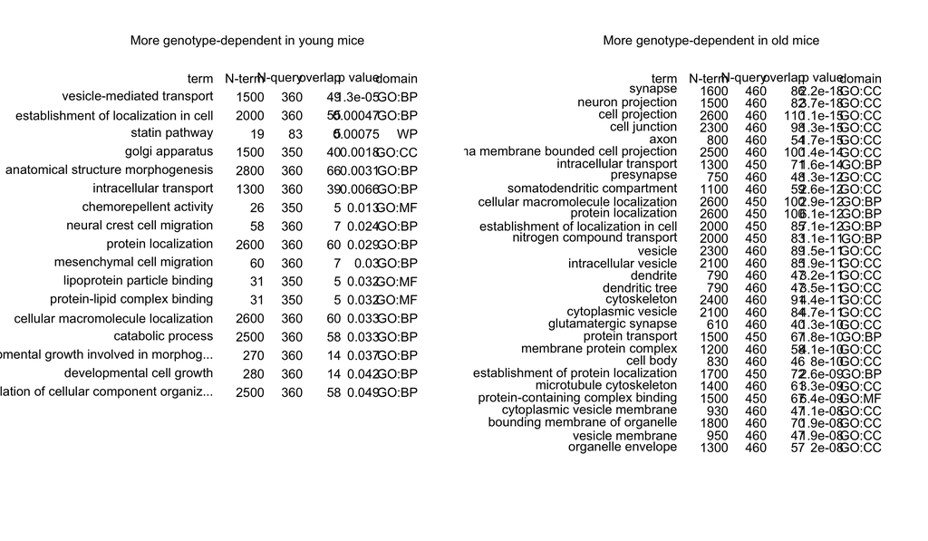

```r
r2.diff <- age.r2[[2]] - age.r2[[1]]
more.in.old <- names(head(sort(r2.diff, decreasing = TRUE), 500))
more.in.young <- names(head(sort(r2.diff, decreasing = FALSE), 500))

more.in.old.enrich <- gost(more.in.old, organism = "mmusculus",
    sources = c("GO", "KEGG", "REACTOME", "HP", "CORUM", "WP"))
more.in.young.enrich <- gost(more.in.young, organism = "mmusculus",
    sources = c("GO", "KEGG", "REACTOME", "HP", "CORUM", "WP"))

#quartz(width = 12, height = 7)
par(mfrow = c(1,2))
plot.enrichment(more.in.young.enrich, plot.label = "More genotype-dependent in young mice",
    max.term.size = 3000, num.terms = 30)
plot.enrichment(more.in.old.enrich, plot.label = "More genotype-dependent in old mice",
    max.term.size = 3000, num.terms = 30)
```

```r
young_v_old <- function(gene.name = NULL, tx.id = NULL){

  if(is.null(tx.id)){
    tx.id <- mouse.gene.table[which(mouse.gene.table[,"external_gene_name"] == gene.name),"ensembl_gene_id"]
  }
  if(is.null(gene.name)){
    gene.name <- mouse.gene.table[which(mouse.gene.table[,"ensembl_gene_id"] == tx.id),"external_gene_name"]
    if(length(gene.name) == 0){
      gene.name <- tx.id
    }
  }

  age.expr <- vector(mode = "list", length = length(age.idx))
  names(age.expr) <- names(age.idx)

  for(a in 1:length(age.idx)){
    quartz()
    age.expr[[a]] <- plot_tx_with_genotype(expr.mat = t(adj.expr[age.idx[[a]],]),
      covar.table = covar[age.idx[[a]],c(1:2,4)], tx_name = tx.id,
      ylab = "Count", tx_label = paste(gene.name, "in", names(age.idx)[a], "animals"),
      pt_col = "#c51b8a", plot.results = TRUE)
  }

  age.mean <- lapply(age.expr, function(x) sapply(x[[1]][[1]], function(y) mean(y)))
  mean.min <- min(unlist(age.mean))
  mean.max <- max(unlist(age.mean))

  ybounds <- get_plot_bounds(mean.min, mean.max, scale.factor = 5)
  plot.height = mean.max - mean.min

  quartz(width = 6, height = 5)
  layout(matrix(c(1,2), nrow = 1, byrow = TRUE), widths = c(1, 0.3))
  par(mar = c(4,4,4,0))
  plot.new()
  plot.window(xlim = c(0.5,2.5), ylim = ybounds)
  for(a in 1:length(age.mean)){
    points(x = rep(a, length(age.mean[[a]])), y = age.mean[[a]], cex = 1.5,
      col = geno.cols[match(names(age.mean[[a]]), names(geno.cols))], pch = 16)
  }
  segments(x0 = rep(1, length(age.mean[[1]])), x1 = rep(2, length(age.mean[[1]])),
    y0 = age.mean[[1]], y1 = age.mean[[2]], lwd = 1.5,
    col = geno.cols[match(names(age.mean[[2]]), names(geno.cols))])
  axis(2, at = round(seq(ybounds[1], ybounds[2], 0.4), 2), las = 2)
  mtext(gene.name, side = 3)
  par(xpd = NA)
  text(x = 1, y = ybounds[1], labels = "4 months")
  text(x = 2, y = ybounds[1], labels = "12 months")
  par(xpd = TRUE)
  par(mar = c(4,0,4,4))
  plot.new()
  plot.window(xlim = c(0,1), ylim = c(0,1))
  legend(x = 0, y = 0.9, legend = names(geno.cols), pch = 16, lty = 1, col = geno.cols)

  quartz()
  interaction.plot(covar[,"age_batch"], covar[,"climb_geno"], adj.expr[,tx.id],
    xlab = "Age", ylab = "Effect", col = geno.cols[match(names(age.mean[[1]]), names(geno.cols))],
    lwd = 3, trace.label = "genotype", main = gene.name)

    invisible(age.mean)
}


young_old_mean <- function(gene.name = NULL, tx.id = NULL){

  if(is.null(tx.id)){
    tx.id <- mouse.gene.table[which(mouse.gene.table[,"external_gene_name"] == gene.name),"ensembl_gene_id"]
  }
  if(is.null(gene.name)){
    gene.name <- mouse.gene.table[which(mouse.gene.table[,"ensembl_gene_id"] == tx.id),"external_gene_name"]
  }

  young.expr <- plot_tx_with_genotype(expr.mat = t(adj.expr[young.idx,]),
    covar.table = covar[young.idx,c(1:2,4)], tx_name = tx.id,
    ylab = "Count", tx_label = paste(gene.name, "in young animals"),
    pt_col = "#c51b8a", plot.results = FALSE)


  old.expr <- plot_tx_with_genotype(expr.mat = t(adj.expr[old.idx,]),
    covar.table = covar[old.idx,c(1:2,4)], tx_name = tx.id,
    ylab = "Count", tx_label = paste(gene.name, "in old animals"),
    pt_col = "#c51b8a", plot.results = FALSE)

    young.mean <- sapply(young.expr$grouped_vals[[1]], mean)
    old.mean <- sapply(old.expr$grouped_vals[[1]], mean)

    result <- list("young_mean" = young.mean, "old_mean" = old.mean)
    return(result)

}
```

We used a linear model to test the interaction between age and genotype for every gene. We identified genes that had a significant interaction between age and genotype for at least one of the genotypes.

The heat map below shows the difference in mean expression between older and younger mice for the nominally significant transcripts. Blue cells indicate that gene expression went down with age in that genotype, and brown cells indicate that gene expression went up with age.

Again we see the two major clusters with FC and VS genotypes opposing each other. Some genes go up in VS and down in FC, and others do the opposite.

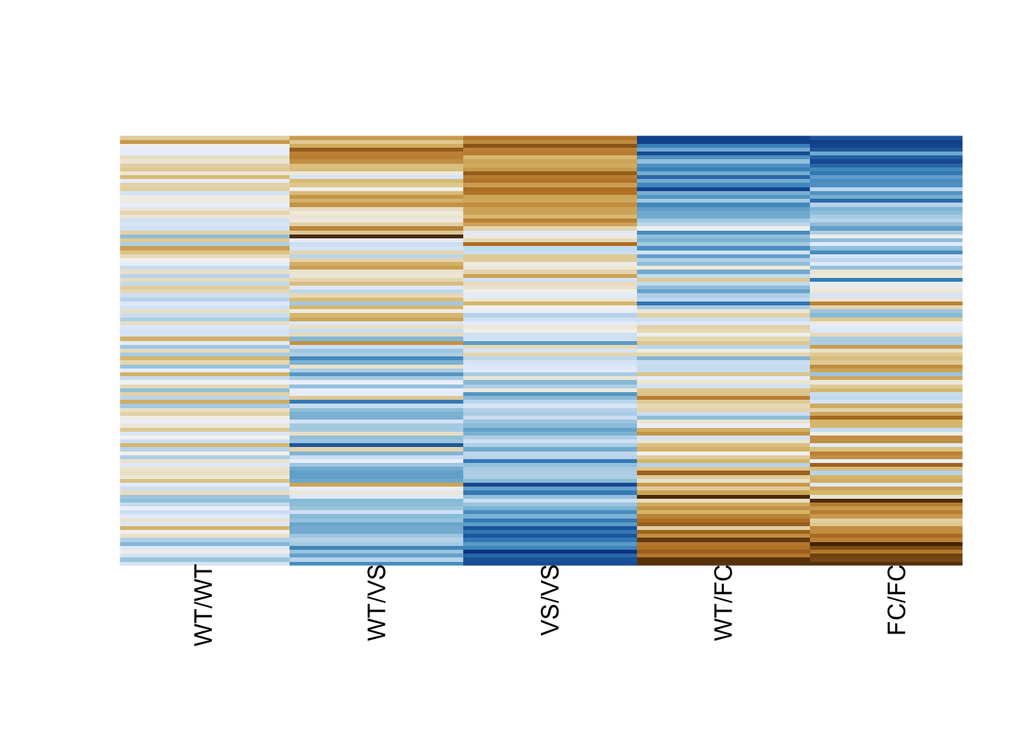

```r
sig.level = 1e-3

geno.fac <- as.factor(covar[,"climb_geno"])
levels(geno.fac) <- c("WT/WT", "WT/FC", "FC/FC", "WT/VS", "VS/VS")

test.int <- apply(adj.expr, 2, function(x) lm(x~as.factor(covar[,"age_batch"])*geno.fac))
test.effect <- t(sapply(test.int, function(x) summary(x)$coefficients[,"Estimate"]))
test.p <- t(sapply(test.int, function(x) summary(x)$coefficients[,"Pr(>|t|)"]))

#the plot below shows the mean expression difference across age
#by genotype for genes with nominally significant interactions
#between age and genotype. The FC/FC genotype seems to have
#the biggest difference in gene expression based on age.

int.col <- 7:10
sig.idx <- apply(test.p[,int.col], 2, function(x) which(x <= sig.level))
sig.tx <- unique(unlist(lapply(sig.idx, names)))

geno.idx <- lapply(age.idx, function(y) lapply(names(geno.cols), function(x) which(covar[y,"climb_geno"] == x)))
tx.mean <- lapply(geno.idx, function(y) sapply(y, function(x) colMeans(adj.expr[x, sig.tx])))

diff.mean <- tx.mean[[2]] - tx.mean[[1]]
colnames(diff.mean) <- names(geno.cols)
row.order <- order(plot.decomp(diff.mean, plot.results = FALSE)$u[,1])
imageWithText(diff.mean[row.order,], show.text = FALSE, split.at.vals = TRUE,
  col.scale = c("blue", "brown"), grad.dir = "ends", row.names = NULL)
```

```r
#plot old and young expression of genes by name
#gene.name <- "Sc5d"; tx.id <- mouse.gene.table[which(mouse.gene.table[,"external_gene_name"] == gene.name),"ensembl_gene_id"]
#tx.id <- "ENSMUSG00000052139"; gene.name <- mouse.gene.table[which(mouse.gene.table[,"ensembl_gene_id"] == tx.id),"external_gene_name"]

young_v_old(gene.name = "Babam2")

young_v_old(tx.id = sig.tx[row.order][4])
young_v_old(tx.id = sig.tx[rev(row.order)][1])

rnd.tx <- sample(sig.tx, 1)
young_v_old(tx.id = rnd.tx)
```

[output not shown]